# cifar_gan_demo

License Agreement - This software is provided under BSD2 license:  
Copyright © 2019 Denis Osipychev < osipychev at gmail dot com >  
Redistribution and use in source and binary forms, with or without modification, are permitted provided that the following conditions are met:

- 1. Redistributions of source code must retain the above copyright notice, this list of conditions and the following disclaimer.
- 2. Redistributions in binary form must reproduce the above copyright notice, this list of conditions and the following disclaimer in the documentation and/or other materials provided with the distribution.

THIS SOFTWARE IS PROVIDED BY THE COPYRIGHT HOLDERS AND CONTRIBUTORS "AS IS" AND ANY EXPRESS OR IMPLIED WARRANTIES, INCLUDING, BUT NOT LIMITED TO, THE IMPLIED WARRANTIES OF MERCHANTABILITY AND FITNESS FOR A PARTICULAR PURPOSE ARE DISCLAIMED. IN NO EVENT SHALL THE COPYRIGHT HOLDER OR CONTRIBUTORS BE LIABLE FOR ANY DIRECT, INDIRECT, INCIDENTAL, SPECIAL, EXEMPLARY, OR CONSEQUENTIAL DAMAGES (INCLUDING, BUT NOT LIMITED TO, PROCUREMENT OF SUBSTITUTE GOODS OR SERVICES; LOSS OF USE, DATA, OR PROFITS; OR BUSINESS INTERRUPTION) HOWEVER CAUSED AND ON ANY THEORY OF LIABILITY, WHETHER IN CONTRACT, STRICT LIABILITY, OR TORT (INCLUDING NEGLIGENCE OR OTHERWISE) ARISING IN ANY WAY OUT OF THE USE OF THIS SOFTWARE, EVEN IF ADVISED OF THE POSSIBILITY OF SUCH DAMAGE.

# Generative Adversarial Network (GAN) with CIFAR10

### by Denis Osipychev < www.denisos.com >

In this demo, I am building a generative adversarial network (GAN) trained on the CIFAR dataset and capable of creating synthetic images following the CIFAR data distribution.

This is an extension of the previous demonstration building a GAN for MNIST dataset. You can find general remarks about GANs there.

### General packages import

```python
# General packages
import numpy as np
import torch
import pickle as pkl

# Data
from torchvision.datasets import CIFAR10
from torchvision import transforms
import torch.utils.data.dataloader as dataloader

# Torch models
import torch.nn as nn
import torch.nn.functional as F
from torchvision import models

# Torch optimization
import torch.optim as optim
from torch.utils.tensorboard import SummaryWriter

# Plotting
import matplotlib.pyplot as plt
%matplotlib inline

device = torch.device('cuda:0' if torch.cuda.is_available() else 'cpu')
```

### Prepare Dataset Loader

```python
tf = transforms.Compose([
    transforms.RandomHorizontalFlip(),
    transforms.ToTensor(),
    transforms.Normalize((0.5, 0.5, 0.5), (0.5, 0.5, 0.5))])

train = CIFAR10('./data', train=True, download=True, transform=tf)
train_loader = dataloader.DataLoader(train, shuffle=True, batch_size=64, num_workers=2, pin_memory=True)
```

```
Files already downloaded and verified
```

### Visualize and Understand the Data

```
Batch data dimensions:  torch.Size([64, 3, 32, 32])
Batch data distribution:  tensor(-1.) tensor(1.) tensor(-0.0344)
```

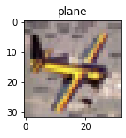

```python
# obtain one batch of training images
dataiter = iter(train_loader)
images, labels = dataiter.next()
print('Batch data dimensions: ', images.size())
print('Batch data distribution: ', torch.min(images), torch.max(images), torch.mean(images))

classes = ('plane', 'car', 'bird', 'cat', 'deer', 'dog', 'frog', 'horse', 'ship', 'truck')
img = images[0].numpy().transpose((1,2,0))/2 + 0.5
label = labels[0].numpy()

plt.figure(figsize=(2,2))
plt.imshow(img)
plt.title(classes[label])
plt.show()
```

### Create a Discriminator

```python
class Discriminator(nn.Module):

    def __init__(self):
        super(Discriminator, self).__init__()

        self.conv1 = nn.Conv2d(3, 64, 3, stride=1, padding=1)
        self.conv2 = nn.Conv2d(64, 128, 3, stride=1, padding=1)
        self.conv3 = nn.Conv2d(128, 256, 3, stride=1, padding=1)
        self.dropout = nn.Dropout(0.5)
        self.fc1 = nn.Linear(4096, 128)
        self.fc2 = nn.Linear(128, 1)

    def forward(self, x):
        norm_noise = 0.1 * torch.randn(x.size(), device=device) # adding noise to input to avoid D overfitting
        x = x + norm_noise
        x = F.leaky_relu(self.conv1(x), 0.2)
        x = F.max_pool2d(x,2)
        x = F.leaky_relu(self.conv2(x), 0.2)
        x = F.max_pool2d(x,2)
        x = F.leaky_relu(self.conv3(x), 0.2)
        x = F.max_pool2d(x,2)
        x = x.view(-1, 4096)
        x = F.leaky_relu(self.fc1(x), 0.2)
        x = self.dropout(x)
        x = torch.sigmoid(self.fc2(x))

        return x

img_shape = images[0].shape
D = Discriminator().to(device)
print(D)
```

```
Discriminator(
  (conv1): Conv2d(3, 64, kernel_size=(3, 3), stride=(1, 1), padding=(1, 1))
  (conv2): Conv2d(64, 128, kernel_size=(3, 3), stride=(1, 1), padding=(1, 1))
  (conv3): Conv2d(128, 256, kernel_size=(3, 3), stride=(1, 1), padding=(1, 1))
  (dropout): Dropout(p=0.5, inplace=False)
  (fc1): Linear(in_features=4096, out_features=128, bias=True)
  (fc2): Linear(in_features=128, out_features=1, bias=True)
)
```

### Create a Generator

Similar to the previous demo, the generator is pretty much a flipped discriminator. It has 3 layers of deconvolution with strides to upsample the features followed by a single convolutional layer to wrap up the image to a cirtain shape. $Tanh$ activation is applied at the end similar to the MNIST GAN.

```python
class Generator(nn.Module):

    def __init__(self, input_size):
        super(Generator, self).__init__()

        self.fc1 = nn.Linear(input_size, 4096)
        self.convt1 = nn.ConvTranspose2d(256, 128, 3, stride=2, padding=0, output_padding=0)
        self.convt2 = nn.ConvTranspose2d(128, 64, 3, stride=2, padding=1, output_padding=0)
        self.convt3 = nn.ConvTranspose2d(64, 64, 3, stride=2, padding=2, output_padding=1)
        self.conv1 = nn.Conv2d(64, 3, 3, stride=1, padding=1)

    def forward(self, x):
        x = F.leaky_relu(self.fc1(x), 0.2) # (input, negative_slope=0.2)
        x = x.view(-1,256,4,4)
        x = F.leaky_relu(self.convt1(x), 0.2)
        x = F.leaky_relu(self.convt2(x), 0.2)
        x = F.leaky_relu(self.convt3(x), 0.2)
        x = torch.tanh(self.conv1(x))
        return x

z_size = 100
G = Generator(z_size).to(device)
print(G)
```

```
Generator(
  (fc1): Linear(in_features=100, out_features=4096, bias=True)
  (convt1): ConvTranspose2d(256, 128, kernel_size=(3, 3), stride=(2, 2))
  (convt2): ConvTranspose2d(128, 64, kernel_size=(3, 3), stride=(2, 2), padding=(1, 1))
  (convt3): ConvTranspose2d(64, 64, kernel_size=(3, 3), stride=(2, 2), padding=(2, 2), output_padding=(1, 1))
  (conv1): Conv2d(64, 3, kernel_size=(3, 3), stride=(1, 1), padding=(1, 1))
)
```

### Create Optimizers

In GANs, the generator and discriminator variables are updated separately. So, we'll compute two separete sets of losses and utilize two independent Adam optimizers.

```python
lr = 0.0002

# Create optimizers for the discriminator and generator
d_optimizer = optim.Adam(D.parameters(), lr)
g_optimizer = optim.Adam(G.parameters(), lr)

loss = nn.BCELoss().to(device)
```

### GAN Training

Training will alternate between training the discriminator and the generator.

#### Discriminator training

1. Compute the discriminator loss on real, training images
2. Compute the discriminator loss on fake, generated images
3. Add up real and fake loss
4. Perform an optimization step

#### Generator training

1. Compute the discriminator loss on fake images, using target labels
2. Perform an optimization step

#### Important thing to note

The discriminator learns to identify the output of the generator. After certain point, it will overfit to the generator and their losses start to diverge. To mitigate this undesired behavior, we apply the following tricks:

1. One-sided label smoothing - avoid discriminator being overconfigent about the prediction
2. Adding normal noise to real images - reduce discriminator performance

More tricks can be found here: https://machinelearningmastery.com/how-to-train-stable-generative-adversarial-networks/

```python
num_epochs = 100
writer = SummaryWriter('./log/gan') #Tensorboard

samples = []
losses = []

# make a fixed vector in latent space to track the evolution of the generator
z_sample = torch.randn(10, z_size, device=device)

# train the network
D.train()
G.train()

update_step = 0
for epoch in range(num_epochs):
    for real_images, _ in train_loader:

        batch_size = real_images.size(0)
        real_images = real_images.to(device)

        # ============================================
        #            TRAIN THE DISCRIMINATOR
        # ============================================

        d_optimizer.zero_grad()

        # Compute loss with real images
        D_real = D(real_images)

        target_labels = 0.9 * torch.ones(batch_size, device=device) # so called label smoothing to avoid D overfitting
        d_real_loss = loss(D_real.squeeze(), target_labels)

        # Compute loss with fake images
        z = torch.randn(batch_size, z_size, device=device)
        fake_images = G(z)
        fake_images = fake_images.detach()
        D_fake = D(fake_images)

        target_labels = torch.zeros(batch_size, device=device)
        d_fake_loss = loss(D_fake.squeeze(), target_labels)

        # add up loss and perform backprop step
        d_loss = d_real_loss + d_fake_loss
        d_loss.backward()
        d_optimizer.step()

        # =========================================
        #            TRAIN THE GENERATOR
        # =========================================

        g_optimizer.zero_grad()

        # Compute generator loss with fake image
        z = torch.randn(2*batch_size, z_size, device=device)
        fake_images = G(z)
        D_fake = D(fake_images)

        target_labels = torch.ones(2*batch_size, device=device)
        g_loss = loss(D_fake.squeeze(), target_labels)

        # perform backprop step
        g_loss.backward()
        g_optimizer.step()

        # Print stats
        update_step += 1
        if update_step%100 == 0:
            dl_mean, gl_mean = torch.mean(d_loss), torch.mean(g_loss)
            writer.add_scalar('Loss/Generator', gl_mean, update_step) #Tensorboard
            writer.add_scalar('Loss/Discriminator', dl_mean, update_step) #Tensorboard
            print('\r Epoch [%d/%d] | d_loss: %f | g_loss: %f'%(epoch+1, num_epochs, dl_mean, gl_mean), end="")


    ## Save progress after each epoch
    losses.append((torch.mean(d_loss), torch.mean(g_loss)))

    G.eval()
    sample = G(z_sample)
    samples.append(sample.to('cpu'))
    G.train()

# Save training samples and the generator model
writer.close() #Tensorboard
torch.save(G, './cifar_gan.pkl')
with open('./cifar_gan_samples.pkl', 'wb') as f:
    pkl.dump(samples, f)
```

```
 Epoch [100/100] | d_loss: 0.999824 | g_loss: 1.063250
```

### Plot Training Loss

Plot the resulted training losses for the generator and discriminator (can also be seen in Tensorboard).

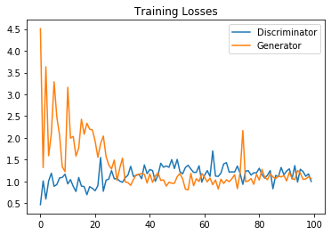

```python
plt.subplots()
losses = np.array(losses)
plt.plot(losses[:,0], label='Discriminator')
plt.plot(losses[:,1], label='Generator')
plt.title('Training Losses')
plt.legend()
```

### Show the Evolution of the Generator

The generator starts with generating a random noize. After each batch update, the generated images look more similar to those in the real dataset.

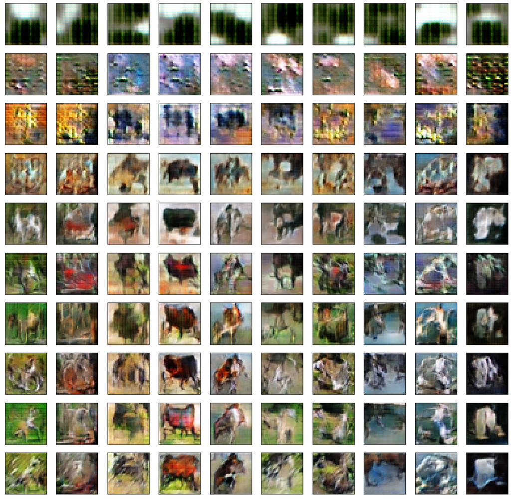

```python
# with open('./cifar_gan_samples.pkl', 'rb') as f:
#     samples = pkl.load(f)

n_rows = 10
n_cols = 10

fig, axes = plt.subplots(figsize=(20,20), nrows=n_rows, ncols=n_cols, sharex=True, sharey=True)
for i_row in range(n_rows):
    for i_col in range(n_cols):
        b = int(len(samples)/n_rows) * i_row
        img = samples[b][i_col]
        img = img.detach()
        img = img.numpy().transpose((1,2,0))/2 + 0.5
        ax = axes[i_row, i_col]
        ax.imshow(img)
        ax.xaxis.set_visible(False)
        ax.yaxis.set_visible(False)
```

### Sampling the Generator

We can also get completely new images from the generator by sampling input vectors in the latent space.

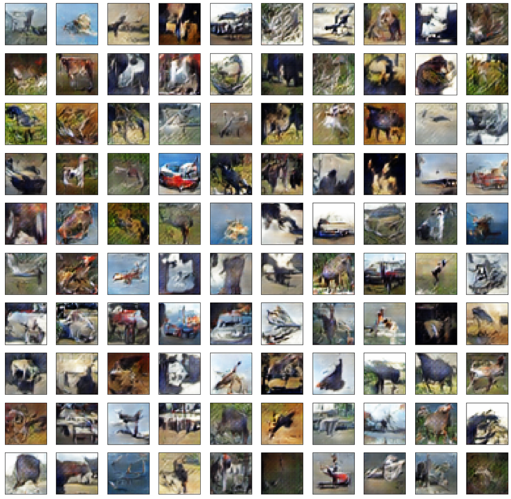

```python
# load generator model
# G = torch.load('./cifar_gan.pkl')

# generate random vectors in latent space and pipe them to the generator
sample_size=100
z = torch.randn(sample_size, z_size, device=device)
E = G.eval()
images = G(z)
images = images.detach().to('cpu')

fig, axes = plt.subplots(figsize=(20,20), nrows=10, ncols=10, sharex=True, sharey=True)
for i in range(sample_size):
    img = images[i]
    img = img.numpy().transpose((1,2,0))/2 + 0.5
    ax = axes[i//10, i%10]
    ax.imshow(img)
    ax.xaxis.set_visible(False)
    ax.yaxis.set_visible(False)
```